# Is the mean time spent on each landing page different for each preferred language?

Let μ1,μ2,μ3 be the means of preferred languages of visitors speaking Spanish, French, and English respectively.

We will test the null hypothesis

$H_0$: μ1=μ2=μ3

against the alternative hypothesis

$H_a$: At least one preferred language is different from the rest.

```
language_preferred
English    6.663750
French     6.196471
Spanish    5.835294
Name: time_spent_on_the_page, dtype: float64
```

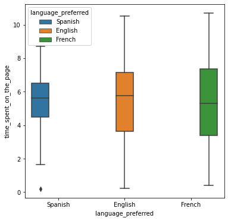

```python
# mean of preferred languages on new page

print(abtest2.groupby("language_preferred")["time_spent_on_the_page"].mean())

# draw the boxplot for visualization
fig, ax = plt.subplots(figsize = (6,6))
a = sns.boxplot(x= "language_preferred", y = 'time_spent_on_the_page' , data = abtest, hue = 'language_preferred')
plt.show()
```

### Now, the normality and equality of variance assumptions need to be checked.

For testing of normality, Shapiro-Wilk’s test is applied to the response variable.

For equality of variance, Levene test is applied to the response variable.

# Shapiro-Wilk’s test

We will test the null hypothesis

$H_0$: Preferred Language follows a normal distribution against

against the alternative hypothesis

$H_a$: Preferred language does not follow a normal distribution

```python
# Assumption 1: Normality
# import the required function
from scipy import stats

# find the p-value
w, p_value = stats.shapiro(abtest['time_spent_on_the_page'])
print('The p-value is', p_value)
```

```
The p-value is 0.5643684267997742
```

Since p-value of the test is very large, we fail to reject the null hypothesis that the response follows the normal distribution.

# Levene’s test

We will test the null hypothesis

$H_0$: All the population variances are equal

against the alternative hypothesis

$H_a$: At least one variance is different from the rest

```python
#Assumption 2: Homogeneity of Variance
#import the required function
from scipy.stats import levene
statistic, p_value = levene( abtest['time_spent_on_the_page'][abtest['language_preferred']=="Spanish"],
                                   abtest['time_spent_on_the_page'][abtest['language_preferred']=="French"],
                                   abtest['time_spent_on_the_page'][abtest['language_preferred']=="English"])
# find the p-value
print('The p-value is', p_value)
```

```
The p-value is 0.06515086840327314
```

Since the p-value is larger than .05, we fail to reject the null hypothesis of homogeneity of variances.

# Are the assumptions are satisfied?

The populations are normally distributed - Yes, the normality assumption is verified using the Shapiro-Wilk’s test.

Samples are independent simple random samples - Yes, we are informed that the collected sample is a simple random sample.

Population variances are equal - Yes, the homogeneity of variance assumption is verified using the Levene's test.

```python
#import the required function
from scipy.stats import f_oneway

# perform one-way anova test
test_stat, p_value = f_oneway(abtest.loc[abtest['language_preferred'] == 'Spanish', 'time_spent_on_the_page'],
                              abtest.loc[abtest['language_preferred'] == 'French', 'time_spent_on_the_page'],
                              abtest.loc[abtest['language_preferred'] == 'English', 'time_spent_on_the_page'])
print('The p-value is ' + str(p_value))
```

```
The p-value is 0.8665610536012648
```

# Multiple Comparison test (Tukey HSD)

$H_0$: μ1=μ2 and μ1=μ3 and μ2=μ3

against the alternative hypothesis

$H_a$: μ1≠μ2 or μ1≠μ3 or μ2≠μ3

```python
#import the required function
from statsmodels.stats.multicomp import pairwise_tukeyhsd

# perform multiple pairwise comparison (Tukey HSD)
m_comp = pairwise_tukeyhsd(endog = abtest['time_spent_on_the_page'], groups = abtest['language_preferred'], alpha = 0.05)
print(m_comp)
```

```
 Multiple Comparison of Means - Tukey HSD, FWER=0.05
=====================================================
 group1  group2 meandiff p-adj   lower  upper  reject
-----------------------------------------------------
English  French  -0.3058 0.8482 -1.7123 1.1006  False
English Spanish  -0.2273    0.9 -1.6338 1.1792  False
 French Spanish   0.0785    0.9 -1.3065 1.4635  False
-----------------------------------------------------
```

The multiple comparison test confirms the previous tests the the null hypothesis is failed to be rejected for any preferred language.